# Descriptive and Graphical Analysis of the Variable and Cutpoint Selection inside Random Forests

Lennart Schneider, Achim Zeileis, Carolin Strobl

2026-08-27

Random forests are a widely used ensemble learning method for classification or regression tasks. However, they are typically used as a black box prediction method that offers only little insight into their inner workings.

In this vignette, we illustrate how the `stablelearner` package can be used to gain insight into this black box by visualizing and summarizing the variable and cutpoint selection of the trees within a random forest.

Recall that, in simple terms, a random forest is a tree ensemble, and the forest is grown by resampling the training data and refitting trees on the resampled data. Contrary to bagging, random forests have the restriction that the number of feature variables randomly sampled as candidates at each node of a tree (in implementations, this is typically called the `mtry` argument) is smaller than the total number of feature variables available. Random forests were introduced by Breiman (2001).

The `stablelearner` package was originally designed to provide functionality for assessing the stability of tree learners and other supervised statistical learners, both visually (Philipp et al. 2016) and by means of computing similarity measures (Philipp et al. 2018), on the basis of repeatedly resampling the training data and refitting the learner.

However, in this vignette we are interested in visualizing the variable and cutpoint selection of the trees within a *random forest*. Therefore, contrary to the original design of the `stablelearner` package, where the aim was to assess the stability of a single original tree, we are not interested in highlighting any single tree, but want all trees to be treated as equal. As a result, some functions will later require to set the argument `original = FALSE`. Moreover, this vignette does not cover similarity measures for random forests, which are still work in progress.

In all sections of this vignette, we are going to work with credit scoring data where applicants are rated as `"good"` or `"bad"`, which will be introduced in Section 1.

In Section 2 we will cover the `stablelearner` package and how to fit a random forest using the `stabletree()` function (Section 2.1). In Section 2.2 we show how to summarize and visualize the variable and cutpoint selection of the trees in a random forest.

In the final Section 3, we will demonstrate how the same summary and visualizations can be produced when working with random forests that were already fitted via the `cforest()` function of the `partykit` package, the `cforest()` function of the `party` package, the `randomForest()` function of the `randomForest` package, or the `ranger()` function of the `ranger` package.

Note that in the following, functions will be specified with the double colon notation, indicating the package they belong to, e.g., `partykit::cforest()` denoting the `cforest()` function of the `partykit` package, while `party::cforest()` denotes the `cforest()` function of the `party` package.

## 1 Data

In all sections we are going to work with the `german` dataset, which is included in the `rchallenge` package (note that this is a transformed version of the German Credit data set with factors instead of dummy variables, and corrected as proposed by Grömping (2019).

```r
data("german", package = "rchallenge")
```

The dataset consists of 1000 observations on 21 variables. For a full description of all variables, see `?rchallenge::german`. The random forest we are going to fit in this vignette predicts whether a person was classified as `"good"` or `"bad"` with respect to the `credit_risk` variable using all other available variables as feature variables. To allow for a lower runtime we only use a subsample of the data (500 persons):

```r
set.seed(2409)
dat <- droplevels(german[sample(seq_len(NROW(german)), size = 500), ])
```

```r
str(dat)
```

```
## 'data.frame':    500 obs. of  21 variables:
##  $ status                 : Factor w/ 4 levels "no checking account",..: 2 4 4..
##  $ duration               : int  30 21 18 24 12 15 7 9 27 12 ...
##  $ credit_history         : Factor w/ 5 levels "delay in paying off in the pa"..
##  $ purpose                : Factor w/ 10 levels "others","car (new)",..: 1 1 4..
##  $ amount                 : int  4249 5003 1505 5743 3331 3594 846 2753 2520 1..
##  $ savings                : Factor w/ 5 levels "unknown/no savings account",....
##  $ employment_duration    : Factor w/ 5 levels "unemployed","< 1 yr",..: 1 3 3..
##  $ installment_rate       : Ord.factor w/ 4 levels ">= 35"<"25 <= ... < 35"<....
##  $ personal_status_sex    : Factor w/ 4 levels "male : divorced/separated",..:..
##  $ other_debtors          : Factor w/ 3 levels "none","co-applicant",..: 1 1 1..
##  $ present_residence      : Ord.factor w/ 4 levels "< 1 yr"<"1 <= ... < 4 yrs"..
##  $ property               : Factor w/ 4 levels "unknown / no property",..: 3 2..
##  $ age                    : int  28 29 32 24 42 46 36 35 23 22 ...
##  $ other_installment_plans: Factor w/ 3 levels "bank","stores",..: 3 1 3 3 2 3..
##  $ housing                : Factor w/ 3 levels "for free","rent",..: 2 2 3 3 2..
##  $ number_credits         : Ord.factor w/ 4 levels "1"<"2-3"<"4-5"<..: 2 2 1 2..
##  $ job                    : Factor w/ 4 levels "unemployed/unskilled - non-re"..
##  $ people_liable          : Factor w/ 2 levels "3 or more","0 to 2": 2 2 2 2 2..
##  $ telephone              : Factor w/ 2 levels "no","yes (under customer name"..
##  $ foreign_worker         : Factor w/ 2 levels "yes","no": 2 2 2 2 2 2 2 2 2 2..
##  $ credit_risk            : Factor w/ 2 levels "bad","good": 1 1 2 2 2 2 2 2 1..
```

## 2 `stablelearner`

### 2.1 Growing a random forest in `stablelearner`

In our first approach, we want to grow a random forest directly in `stablelearner`. This is possible using conditional inference trees (Hothorn et al. 2006) as base learners relying on the function `ctree()` of the `partykit` package. This procedure results in a forest equal to a random forest fitted via `partykit::cforest()`.

To achieve this, we have to make sure that our initial `ctree`, that will be repeatedly refitted on the resampled data, is specified correctly with respect to the resampling method and the number of feature variables randomly sampled as candidates at each node of a tree (argument `mtry`). By default, `partykit::cforest()` uses subsampling with a fraction of `0.632` and sets `mtry = ceiling(sqrt(nvar))`. In our example, this would be `5`, as this dataset includes 20 feature variables. Note that setting `mtry` equal to the number of all feature variables available would result in bagging. In a real analysis `mtry` should be tuned by means of, e.g., cross-validation.

We now fit our initial tree, mimicking the defaults of `partykit::cforest()` (see `?partykit::cforest` and `?partykit::ctree_control` for a description of the arguments `teststat`, `testtype`, `mincriterion` and `saveinfo`). The formula `credit_risk ~ .` simply indicates that we use all remaining variables of `dat` as feature variables to predict the `credit_risk` of a person.

```r
set.seed(2906)
ct_partykit <- partykit::ctree(credit_risk ~ ., data = dat,
  control = partykit::ctree_control(mtry = 5, teststat = "quadratic",
    testtype = "Univariate", mincriterion = 0, saveinfo = FALSE))
```

We can now proceed to grow our forest based on this initial tree, using `stablelearner::stabletree()`. We use subsampling with a fraction of `v = 0.632` and grow `B = 100` trees. We set `savetrees = TRUE`, to be able to extract the individual trees later:

```r
set.seed(2907)
cf_stablelearner <- stablelearner::stabletree(ct_partykit,
  sampler = stablelearner::subsampling, savetrees = TRUE, B = 100, v = 0.632)
```

Internally, `stablelearner::stabletree()` does the following: For each of the 100 trees to be generated, the dataset is resampled according to the resampling method specified (in our case subsampling with a fraction of `v = 0.632`) and the function call of our initial tree (which we labeled `ct_partykit`) is updated with respect to this resampled data and reevaluated, resulting in a new tree. All the 100 trees together then build the forest.

### 2.2 Gaining insight into the forest

The following summary prints the variable selection frequency (`freq`) as well as the average number of splits in each variable (`mean`) over all 100 trees. As we do *not* want to focus on our initial tree (remember that we just grew a forest, where all trees are of equal interest), we set `original = FALSE`, as already mentioned in the introduction:

```r
summary(cf_stablelearner, original = FALSE)
```

```
##
## Call:
## partykit::ctree(formula = credit_risk ~ ., data = dat, control = partykit::ctree_control(mtry = 5,
##     teststat = "quadratic", testtype = "Univariate", mincriterion = 0,
##     saveinfo = FALSE))
##
## Sampler:
## B = 100
## Method = Subsampling with 63.2% data
##
## Variable selection overview:
##
##                         freq mean
## status                  0.96 2.38
## duration                0.88 1.72
## credit_history          0.88 1.69
## employment_duration     0.87 1.62
## amount                  0.83 1.41
## age                     0.80 1.34
## property                0.75 1.19
## purpose                 0.72 1.23
## present_residence       0.71 1.11
## savings                 0.69 1.01
## housing                 0.69 1.00
## installment_rate        0.68 1.12
## number_credits          0.64 0.82
## job                     0.61 0.80
## personal_status_sex     0.60 0.87
## telephone               0.55 0.75
## other_installment_plans 0.53 0.65
## other_debtors           0.40 0.41
## people_liable           0.39 0.47
## foreign_worker          0.19 0.19
```

Plotting the variable selection frequency is achieved via the following command (note that `cex.names` allows us to specify the relative font size of the x-axis labels):

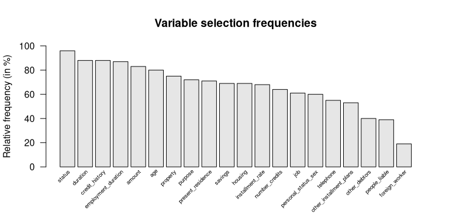

```r
barplot(cf_stablelearner, original = FALSE, cex.names = 0.6)
```

To get a more detailed view, we can also inspect the variable selection patterns displayed for each tree. The following plot shows us for each variable whether it was selected (colored in darkgrey) in each of the 100 trees within the forest, where the variables are ordered on the x-axis so that top ranking ones come first:

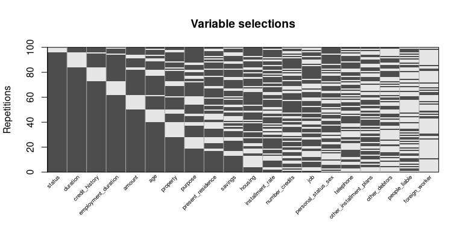

```r
image(cf_stablelearner, original = FALSE, cex.names = 0.6)
```

This may allow for interesting observations, e.g., we observe that in those trees where `duration` was not selected, both `credit_history` and `employment_duration` were almost always selected as splitting variables.

Finally, the `plot()` function allows us to inspect the cutpoints and resulting partitions for each variable over all 100 trees. Here we focus on the variables `status`, `present_residence`, and `duration`:

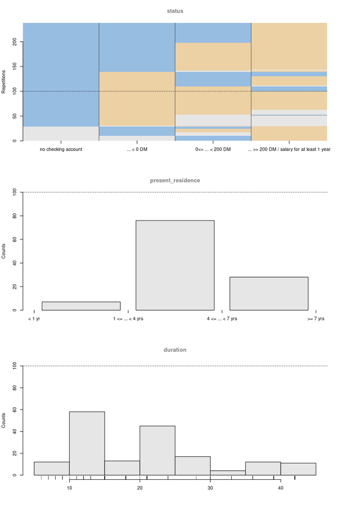

```r
plot(cf_stablelearner, original = FALSE,
  select = c("status", "present_residence", "duration"))
```

Looking at the first variable `status` (an unordered categorical variable), we are given a so called image plot, visualizing the partition of this variable for each of the 100 trees.. We observe that the most frequent partition is to distinguish between persons with the values `no checking account` and `... < 0 DM` vs. persons with the values `0 <= ... < 200 DM` and `... >= 200 DM / salary for at least 1 year`, but also other partitions occur. The light gray color is used when a category was no more represented by the observations left for partitioning in the particular node.

For ordered categorical variables such as `present_residence`, a barplot is given showing the frequency of all possible cutpoints sorted on the x-axis in their natural order. Here, the cutpoint between `1 <= ... < 4 years` and `4 <= ... < 7 years` is selected most frequently.

Lastly, for numerical variables a histogram is given, showing the distribution of cutpoints. We observe that most cutpoints for the variable `duration` occurred between 0 and 30, but there appears to be high variance, indicating a smooth effect of this variable rather than a pattern with a distinct change-point.

For a more detailed explanation of the different kinds of plots, Section 3 of Philipp et al. (2016) is very helpful.

To conclude, the summary table and different plots helped us to gain some insight into the variable and cutpoint selection of the 100 trees within our forest. Finally, in case we want to extract individual trees, e.g., the first tree, we can do this via:

```r
cf_stablelearner$tree[[1]]
```

It should be noted that from a technical and performance-wise perspective, there is little reason to grow a forest directly in `stablelearner`, as the `cforest()` implementations in `partykit` and especially in `party` are more efficient. Nevertheless, it should be noted that the approach of growing a forest directly in `stablelearner` allows us to be more flexible with respect to, e.g., the resampling method, as we could specify any method we want, e.g., bootstrap, subsampling, samplesplitting, jackknife, splithalf or even custom samplers. For a discussion why subsampling should be preferred over bootstrap sampling, see Strobl et al. (2007).

## 3 Working with random forests fitted via other packages

In this final section we cover how to work with random forests that have already been fitted via the `cforest()` function of the `partykit` package, the `cforest()` function of the `party` package, the `randomForest()` function of the `randomForest` package, or the `ranger()` function of the `ranger` package.

Essentially, we just fit the random forest and then use `stablelearner::as.stabletree()` to coerce the forest to a `stabletree` object, which allows us to get the same summary and plots as presented above.

Fitting a `cforest` with 100 trees using `partykit` is straightforward:

```r
set.seed(2908)
cf_partykit <- partykit::cforest(credit_risk ~ ., data = dat,
  ntree = 100, mtry = 5)
```

`stablelearner::as.stabletree()` then allows us to coerce this `cforest` and we can produce summaries and plots as above (note that for plotting, we can now omit `original = FALSE`, because the coerced forest has no particular initial tree):

```r
cf_partykit_st <- stablelearner::as.stabletree(cf_partykit)
summary(cf_partykit_st, original = FALSE)
barplot(cf_partykit_st)
image(cf_partykit_st)
plot(cf_partykit_st, select = c("status", "present_residence", "duration"))
```

We do not observe substantial differences compared to growing the forest directly in `stablelearner` (of course, this is the expected behavior, because we tried to mimic the algorithm of `partykit::cforest()` in the previous section), therefore we will not display the results again.

Looking at the variable importance as reported by `partykit::varimp()` shows substantial overlap, i.e., the variable `status` yields a high importance:

```r
partykit::varimp(cf_partykit)
```

```
##                  status                duration          credit_history
##             0.247738374             0.034059673             0.077873676
##                 purpose                  amount                 savings
##            -0.004825073             0.031340832             0.040444307
##     employment_duration        installment_rate     personal_status_sex
##             0.016477162            -0.022483572            -0.004295483
##           other_debtors       present_residence                property
##             0.020315372             0.001464200             0.008682788
##                     age other_installment_plans                 housing
##             0.058371493             0.046699228             0.031434510
##          number_credits                     job           people_liable
##             0.011540270            -0.022146762             0.014946051
##               telephone          foreign_worker
##            -0.011154765             0.024520948
```

The coercing procedure described above is analogous for forests fitted via `party::cforest()`:

```r
set.seed(2909)
cf_party <- party::cforest(credit_risk ~ ., data = dat,
  control = party::cforest_unbiased(ntree = 100, mtry = 5))
```

```r
cf_party_st <- stablelearner::as.stabletree(cf_party)
summary(cf_party_st, original = FALSE)
barplot(cf_party_st)
image(cf_party_st)
plot(cf_party_st, select = c("status", "present_residence", "duration"))
```

Again, we do not observe substantial differences compared to `partykit::cforest()`. This is the expected behavior, as `partykit::cforest()` is a (pure R) reimplementation of `party::cforest()` (implemented in C).

For forests fitted via `randomForest::randomForest`, we can do the same as above. However, as these forests are not using conditional inference trees as base learners, we can expect some difference with respect to the results:

```r
set.seed(2910)
rf <- randomForest::randomForest(credit_risk ~ ., data = dat,
  ntree = 100, mtry = 5)
```

```r
rf_st <- stablelearner::as.stabletree(rf)
summary(rf_st, original = FALSE)
```

```
##
## Call:
## randomForest(formula = credit_risk ~ ., data = dat, ntree = 100,
##     mtry = 5)
##
## Sampler:
## B = 100
## Method = randomForest::randomForest
##
## Variable selection overview:
##
##                         freq  mean
## status                  1.00  4.79
## duration                1.00  7.82
## credit_history          1.00  4.23
## purpose                 1.00  6.27
## amount                  1.00 10.81
## savings                 1.00  4.32
## employment_duration     1.00  5.64
## installment_rate        1.00  4.66
## property                1.00  4.50
## age                     1.00  9.08
## personal_status_sex     0.99  3.47
## present_residence       0.99  4.40
## job                     0.97  3.17
## other_installment_plans 0.94  2.26
## number_credits          0.94  2.26
## housing                 0.93  2.41
## telephone               0.85  1.90
## other_debtors           0.83  1.57
## people_liable           0.73  1.09
## foreign_worker          0.43  0.48
```

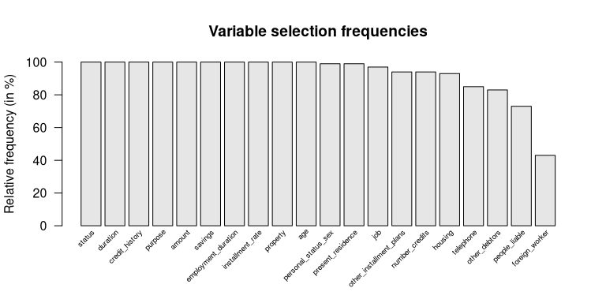

```r
barplot(rf_st, cex.names = 0.6)
```

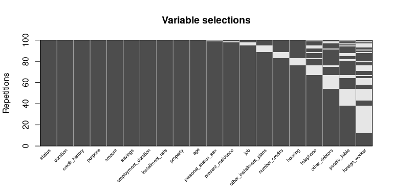

```r
image(rf_st, cex.names = 0.6)
```

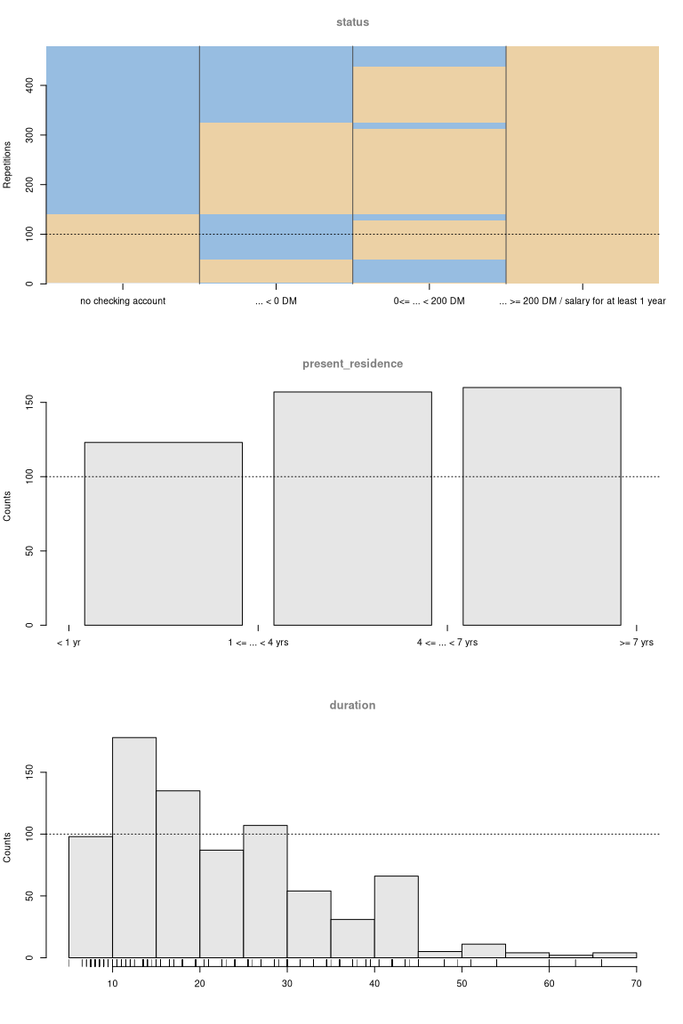

```r
plot(rf_st, select = c("status", "present_residence", "duration"))
```

We observe that for numerical variables the average number of splits is much higher now, i.e., `amount` is selected at an average of around 10 times. Their preference for variables offering many cutpoints is a known drawback of Breiman and Cutler’s original Random Forest algorithm, which random forests based on conditional inference trees do not share. Note, however, that Breiman and Cutler did not intend the variable selection frequencies to be used as a measure of the relevance of the predictor variables, but have suggested a permutation-based variable importance measure for this purpose. For more details, see Hothorn et al. (2006), Strobl et al. (2007), and Strobl et al. (2009).

Finally, for forests fitted via `ranger::ranger()` (that also implements Breiman and Cutler’s original algorithm), the coercing procedure is again the same:

```r
set.seed(2911)
rf_ranger <- ranger::ranger(credit_risk ~ ., data = dat,
  num.trees = 100, mtry = 5)
```

```r
rf_ranger_st <- stablelearner::as.stabletree(rf_ranger)
summary(rf_ranger_st, original = FALSE)
barplot(rf_ranger_st)
image(rf_ranger_st)
plot(rf_ranger_st, select = c("status", "present_residence", "duration"))
```

As a final comment on computational performance, note that just as `stablelearner::stabletree()`, `stablelearner::as.stabletree()` allows for parallel computation (see the arguments `applyfun` and `cores`). This may be helpful when dealing with the coercion of large random forests.

## References

Breiman, L. 2001. “Random Forests.” *Machine Learning* 45 (1): 5–32. https://doi.org/10.1023/a:1010933404324.

Grömping, U. 2019. *South German Credit Data: Correcting a Widely Used Data Set*. Beuth University of Applied Sciences Berlin, Department II.

Hothorn, T., K. Hornik, and A. Zeileis. 2006. “Unbiased Recursive Partitioning: A Conditional Inference Framework.” *Journal of Computational and Graphical Statistics* 15 (3): 651–74. https://doi.org/10.1198/106186006x133933.

Philipp, M., T. Rusch, K. Hornik, and C. Strobl. 2018. “Measuring the Stability of Results from Supervised Statistical Learning.” *Journal of Computational and Graphical Statistics* 27 (4): 685–700. https://doi.org/10.1080/10618600.2018.1473779.

Philipp, M., A. Zeileis, and C. Strobl. 2016. “A Toolkit for Stability Assessment of Tree-Based Learners.” In *Proceedings of COMPSTAT 2016 – 22nd International Conference on Computational Statistics*, edited by A. Colubi, A. Blanco, and C. Gatu. The International Statistical Institute/International Association for Statistical Computing.

Strobl, C., A.-L. Boulesteix, A. Zeileis, and T. Hothorn. 2007. “Bias in Random Forest Variable Importance Measures: Illustrations, Sources and a Solution.” *BMC Bioinformatics* 8 (25). https://doi.org/10.1186/1471-2105-8-25.

Strobl, C., J. Malley, and G. Tutz. 2009. “An Introduction to Recursive Partitioning: Rationale, Application, and Characteristics of Classification and Regression Trees, Bagging, and Random Forests.” *Psychological Methods* 14 (4): 323–48. https://doi.org/10.1037/a0016973.